# Solution_INN_Learner_Notebook_Full_code

Bank Churn Prediction

## Problem Statement

### Context

Businesses like banks which provide service have to worry about problem of 'Customer Churn' i.e. customers leaving and joining another service provider. It is important to understand which aspects of the service influence a customer's decision in this regard. Management can concentrate efforts on improvement of service, keeping in mind these priorities.

### Objective

You as a Data scientist with the bank need to build a neural network based classifier that can determine whether a customer will leave the bank or not in the next 6 months.

### Data Dictionary

- CustomerId: Unique ID which is assigned to each customer
- Surname: Last name of the customer
- CreditScore: It defines the credit history of the customer.
- Geography: A customer’s location
- Gender: It defines the Gender of the customer
- Age: Age of the customer
- Tenure: Number of years for which the customer has been with the bank
- NumOfProducts: refers to the number of products that a customer has purchased through the bank.
- Balance: Account balance
- HasCrCard: It is a categorical variable which decides whether the customer has credit card or not.
- EstimatedSalary: Estimated salary
- isActiveMember: Is is a categorical variable which decides whether the customer is active member of the bank or not ( Active member in the sense, using bank products regularly, making transactions etc )
- Exited : whether or not the customer left the bank within six month. It can take two values ** 0=No ( Customer did not leave the bank ) ** 1=Yes ( Customer left the bank )

## Importing necessary libraries

```python
# Installing the libraries with the specified version.
!pip install tensorflow==2.17.0 scikit-learn==1.3.1 seaborn==0.13.1 matplotlib==3.8.0 numpy==1.25.2 pandas==2.2.2 imbalanced-learn==0.10.1 -q --user --no-warn-script-location
```

```
   ━━━━━━━━━━━━━━━━━━━━━━━━━━━━━━━━━━━━━━━━ 601.3/601.3 MB 2.8 MB/s eta 0:00:00
   ━━━━━━━━━━━━━━━━━━━━━━━━━━━━━━━━━━━━━━━━ 10.9/10.9 MB 61.8 MB/s eta 0:00:00
   ━━━━━━━━━━━━━━━━━━━━━━━━━━━━━━━━━━━━━━━━ 294.8/294.8 kB 24.3 MB/s eta 0:00:00
   ━━━━━━━━━━━━━━━━━━━━━━━━━━━━━━━━━━━━━━━━ 11.6/11.6 MB 76.8 MB/s eta 0:00:00
   ━━━━━━━━━━━━━━━━━━━━━━━━━━━━━━━━━━━━━━━━ 18.2/18.2 MB 24.4 MB/s eta 0:00:00
   ━━━━━━━━━━━━━━━━━━━━━━━━━━━━━━━━━━━━━━━━ 226.0/226.0 kB 14.8 MB/s eta 0:00:00
```

```python
# Libraries to help with reading and manipulating data
import pandas as pd
import numpy as np

# libaries to help with data visualization
import matplotlib.pyplot as plt
import seaborn as sns

# Library to split data
from sklearn.model_selection import train_test_split

# Importing tools for data preprocessing including label encoding, one-hot encoding, and standard scaling
from sklearn.preprocessing import LabelEncoder, OneHotEncoder,StandardScaler

# Importing a class for imputing missing values in datasets.
from sklearn.impute import SimpleImputer

# Importing functions for evaluating the performance of machine learning models
from sklearn.metrics import confusion_matrix, f1_score, accuracy_score, precision_score, recall_score, roc_curve, classification_report

# Importing SMOTE
from imblearn.over_sampling import SMOTE

# Importing different functions to build models
import tensorflow as tf
from tensorflow import keras
from keras import backend
from keras.models import Sequential
from keras.layers import Dense, Dropout, Input, BatchNormalization

import random

# Time related functions.
import time

# Library to suppress unnecessary warnings
import warnings
warnings.filterwarnings("ignore")
```

## Loading the dataset

```python
#Import the package and Mount the drive
from google.colab import drive
drive.mount('/content/drive')
```

```python
# Reading the dataset
ds = pd.read_csv("/content/drive/MyDrive/PGP-AIML/Neural Networks/Project - Bank Churn Prediction/Churn.csv")

# Keeping a copy of the original dataset
ds_orig = ds.copy()
```

## Data Overview

### View the first 5 rows of the dataset.

```python
ds.head()
```

|  | RowNumber | CustomerId | Surname | CreditScore | Geography | Gender | Age | Tenure | Balance | NumOfProducts | HasCrCard | IsActiveMember | EstimatedSalary | Exited |
| --- | --- | --- | --- | --- | --- | --- | --- | --- | --- | --- | --- | --- | --- | --- |
| 0 | 1 | 15634602 | Hargrave | 619 | France | Female | 42 | 2 | 0.00 | 1 | 1 | 1 | 101348.88 | 1 |
| 1 | 2 | 15647311 | Hill | 608 | Spain | Female | 41 | 1 | 83807.86 | 1 | 0 | 1 | 112542.58 | 0 |
| 2 | 3 | 15619304 | Onio | 502 | France | Female | 42 | 8 | 159660.80 | 3 | 1 | 0 | 113931.57 | 1 |
| 3 | 4 | 15701354 | Boni | 699 | France | Female | 39 | 1 | 0.00 | 2 | 0 | 0 | 93826.63 | 0 |
| 4 | 5 | 15737888 | Mitchell | 850 | Spain | Female | 43 | 2 | 125510.82 | 1 | 1 | 1 | 79084.10 | 0 |

### View the last 5 rows of the dataset.

```python
ds.tail()
```

|  | RowNumber | CustomerId | Surname | CreditScore | Geography | Gender | Age | Tenure | Balance | NumOfProducts | HasCrCard | IsActiveMember | EstimatedSalary | Exited |
| --- | --- | --- | --- | --- | --- | --- | --- | --- | --- | --- | --- | --- | --- | --- |
| 9995 | 9996 | 15606229 | Obijiaku | 771 | France | Male | 39 | 5 | 0.00 | 2 | 1 | 0 | 96270.64 | 0 |
| 9996 | 9997 | 15569892 | Johnstone | 516 | France | Male | 35 | 10 | 57369.61 | 1 | 1 | 1 | 101699.77 | 0 |
| 9997 | 9998 | 15584532 | Liu | 709 | France | Female | 36 | 7 | 0.00 | 1 | 0 | 1 | 42085.58 | 1 |
| 9998 | 9999 | 15682355 | Sabbatini | 772 | Germany | Male | 42 | 3 | 75075.31 | 2 | 1 | 0 | 92888.52 | 1 |
| 9999 | 10000 | 15628319 | Walker | 792 | France | Female | 28 | 4 | 130142.79 | 1 | 1 | 0 | 38190.78 | 0 |

### Understand the shape of the dataset

```python
ds.shape
```

```
(10000, 14)
```

**Observation**: The dataset consists of 10,000 rows and 14 columns.

### Check the data types of the columns for the dataset

```python
ds.info()
```

```
<class 'pandas.core.frame.DataFrame'>
RangeIndex: 10000 entries, 0 to 9999
Data columns (total 14 columns):
 #   Column           Non-Null Count  Dtype
---  ------           --------------  -----
 0   RowNumber        10000 non-null  int64
 1   CustomerId       10000 non-null  int64
 2   Surname          10000 non-null  object
 3   CreditScore      10000 non-null  int64
 4   Geography        10000 non-null  object
 5   Gender           10000 non-null  object
 6   Age              10000 non-null  int64
 7   Tenure           10000 non-null  int64
 8   Balance          10000 non-null  float64
 9   NumOfProducts    10000 non-null  int64
 10  HasCrCard        10000 non-null  int64
 11  IsActiveMember   10000 non-null  int64
 12  EstimatedSalary  10000 non-null  float64
 13  Exited           10000 non-null  int64
dtypes: float64(2), int64(9), object(3)
memory usage: 1.1+ MB
```

**Observation**: There are 3 columns of Object type and rest are numerical type i.e. int or float.

### Checking the Statistical Summary

```python
ds.describe().T
```

|  | count | mean | std | min | 25% | 50% | 75% | max |
| --- | --- | --- | --- | --- | --- | --- | --- | --- |
| RowNumber | 10000.0 | 5.000500e+03 | 2886.895680 | 1.00 | 2500.75 | 5.000500e+03 | 7.500250e+03 | 10000.00 |
| CustomerId | 10000.0 | 1.569094e+07 | 71936.186123 | 15565701.00 | 15628528.25 | 1.569074e+07 | 1.575323e+07 | 15815690.00 |
| CreditScore | 10000.0 | 6.505288e+02 | 96.653299 | 350.00 | 584.00 | 6.520000e+02 | 7.180000e+02 | 850.00 |
| Age | 10000.0 | 3.892180e+01 | 10.487806 | 18.00 | 32.00 | 3.700000e+01 | 4.400000e+01 | 92.00 |
| Tenure | 10000.0 | 5.012800e+00 | 2.892174 | 0.00 | 3.00 | 5.000000e+00 | 7.000000e+00 | 10.00 |
| Balance | 10000.0 | 7.648589e+04 | 62397.405202 | 0.00 | 0.00 | 9.719854e+04 | 1.276442e+05 | 250898.09 |
| NumOfProducts | 10000.0 | 1.530200e+00 | 0.581654 | 1.00 | 1.00 | 1.000000e+00 | 2.000000e+00 | 4.00 |
| HasCrCard | 10000.0 | 7.055000e-01 | 0.455840 | 0.00 | 0.00 | 1.000000e+00 | 1.000000e+00 | 1.00 |
| IsActiveMember | 10000.0 | 5.151000e-01 | 0.499797 | 0.00 | 0.00 | 1.000000e+00 | 1.000000e+00 | 1.00 |
| EstimatedSalary | 10000.0 | 1.000902e+05 | 57510.492818 | 11.58 | 51002.11 | 1.001939e+05 | 1.493882e+05 | 199992.48 |
| Exited | 10000.0 | 2.037000e-01 | 0.402769 | 0.00 | 0.00 | 0.000000e+00 | 0.000000e+00 | 1.00 |

### Checking for Missing Values

```python
# let's check for missing values in the data
ds.isnull().sum()
```

|  | 0 |
| --- | --- |
| RowNumber | 0 |
| CustomerId | 0 |
| Surname | 0 |
| CreditScore | 0 |
| Geography | 0 |
| Gender | 0 |
| Age | 0 |
| Tenure | 0 |
| Balance | 0 |
| NumOfProducts | 0 |
| HasCrCard | 0 |
| IsActiveMember | 0 |
| EstimatedSalary | 0 |
| Exited | 0 |

**dtype:** int64

**Observations**: There are no null or missing values in the dataset

### Checking for unique values for each of the column

```python
ds.nunique()
```

|  | 0 |
| --- | --- |
| RowNumber | 10000 |
| CustomerId | 10000 |
| Surname | 2932 |
| CreditScore | 460 |
| Geography | 3 |
| Gender | 2 |
| Age | 70 |
| Tenure | 11 |
| Balance | 6382 |
| NumOfProducts | 4 |
| HasCrCard | 2 |
| IsActiveMember | 2 |
| EstimatedSalary | 9999 |
| Exited | 2 |

**dtype:** int64

```python
# RowNumber, CustomerId and Surname are unique hence dropping them.
ds = ds.drop(['RowNumber', 'CustomerId', 'Surname'], axis=1)
```

## Exploratory Data Analysis

### Univariate Analysis

```python
# function to plot a boxplot and a histogram along the same scale.


def histogram_boxplot(data, feature, figsize=(12, 7), kde=False, bins=None):
    """
    Boxplot and histogram combined

    data: dataframe
    feature: dataframe column
    figsize: size of figure (default (12,7))
    kde: whether to show the density curve (default False)
    bins: number of bins for histogram (default None)
    """
    f2, (ax_box2, ax_hist2) = plt.subplots(
        nrows=2,  # Number of rows of the subplot grid= 2
        sharex=True,  # x-axis will be shared among all subplots
        gridspec_kw={"height_ratios": (0.25, 0.75)},
        figsize=figsize,
    )  # creating the 2 subplots
    sns.boxplot(
        data=data, x=feature, ax=ax_box2, showmeans=True, color="violet"
    )  # boxplot will be created and a star will indicate the mean value of the column
    sns.histplot(
        data=data, x=feature, kde=kde, ax=ax_hist2, bins=bins, palette="winter"
    ) if bins else sns.histplot(
        data=data, x=feature, kde=kde, ax=ax_hist2
    )  # For histogram
    ax_hist2.axvline(
        data[feature].mean(), color="green", linestyle="--"
    )  # Add mean to the histogram
    ax_hist2.axvline(
        data[feature].median(), color="black", linestyle="-"
    )  # Add median to the histogram
```

```python
# function to create labeled barplots


def labeled_barplot(data, feature, perc=False, n=None):
    """
    Barplot with percentage at the top

    data: dataframe
    feature: dataframe column
    perc: whether to display percentages instead of count (default is False)
    n: displays the top n category levels (default is None, i.e., display all levels)
    """

    total = len(data[feature])  # length of the column
    count = data[feature].nunique()
    if n is None:
        plt.figure(figsize=(count + 1, 5))
    else:
        plt.figure(figsize=(n + 1, 5))

    plt.xticks(rotation=90, fontsize=15)
    ax = sns.countplot(
        data=data,
        x=feature,
        palette="Paired",
        order=data[feature].value_counts().index[:n].sort_values(),
    )

    for p in ax.patches:
        if perc == True:
            label = "{:.1f}%".format(
                100 * p.get_height() / total
            )  # percentage of each class of the category
        else:
            label = p.get_height()  # count of each level of the category

        x = p.get_x() + p.get_width() / 2  # width of the plot
        y = p.get_height()  # height of the plot

        ax.annotate(
            label,
            (x, y),
            ha="center",
            va="center",
            size=12,
            xytext=(0, 5),
            textcoords="offset points",
        )  # annotate the percentage

    plt.show()  # show the plot
```

#### Observations on CreditScore

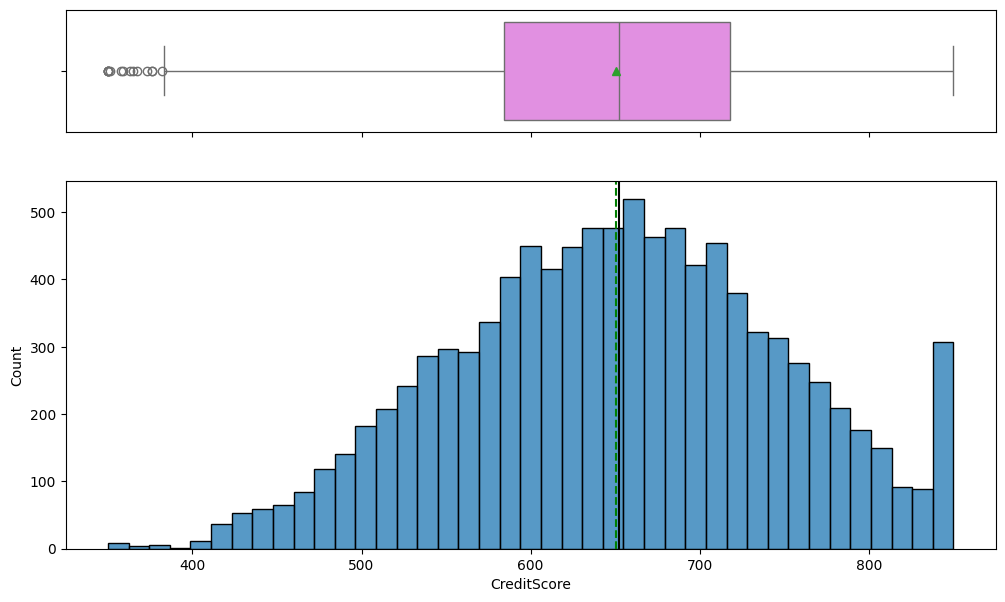

```python
histogram_boxplot(ds,'CreditScore')
```

**Observations**: The mean and median are almost aligned as shown by the box plot. However, there are some outliers below the left whisker. i.e. few customers have a credit score lower than 400.

#### Observations on Age

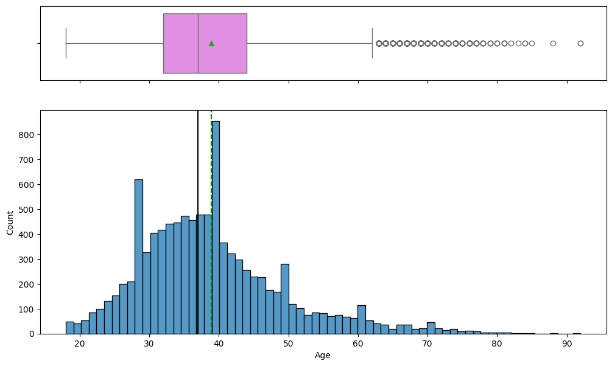

```python
histogram_boxplot(ds,'Age')
```

**Observations**: The age distribution is right-skewed with several outliers beyond the right whisker. These outliers align with the dataset and do not necessitate removal.

#### Observations on Balance

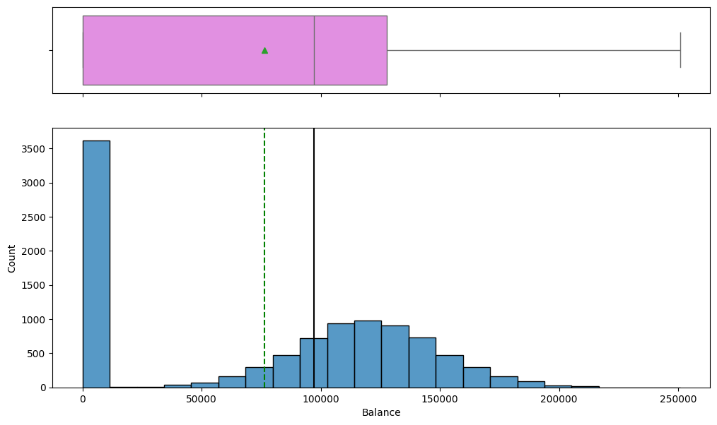

```python
histogram_boxplot(ds,'Balance')
```

#### Observations on Estimated Salary

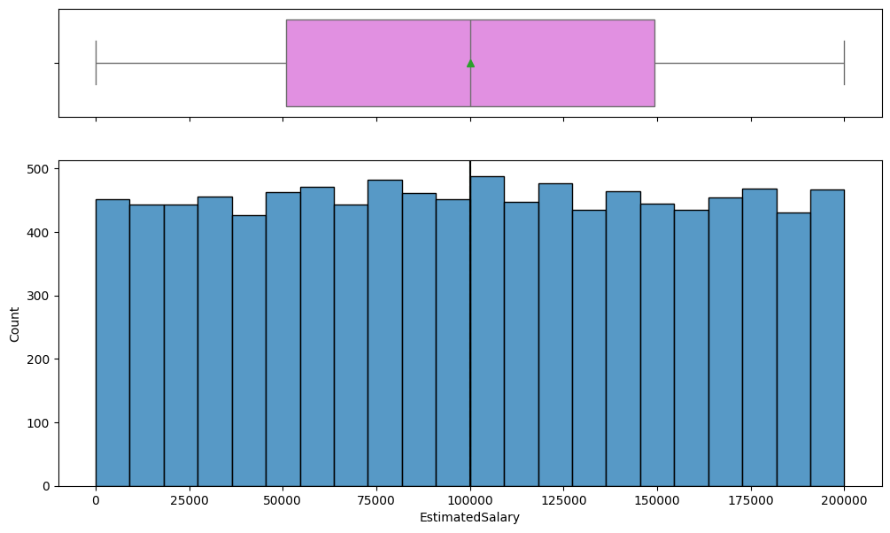

```python
histogram_boxplot(ds,'EstimatedSalary')
```

#### Observations on Exited

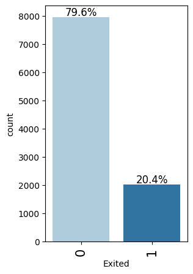

```python
labeled_barplot(ds, "Exited", perc=True)
```

**Observations**: Around 20% of customers have exited, while 80% remain. This highlights an imbalance in the target variable that should be addressed during modeling.

#### Observations on Geography

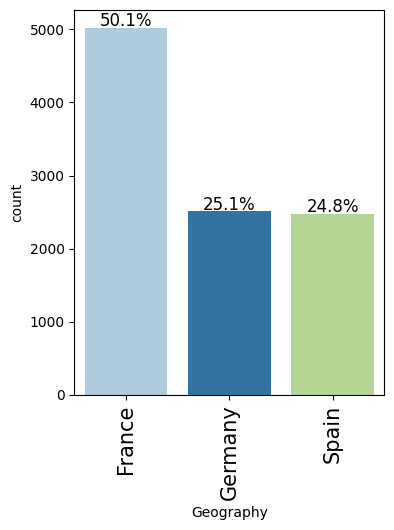

```python
labeled_barplot(ds, "Geography", perc=True)
```

**Observations**: The customer base comprises 50% from France, 25% from Germany, and 25% from Spain.

#### Observations on Gender

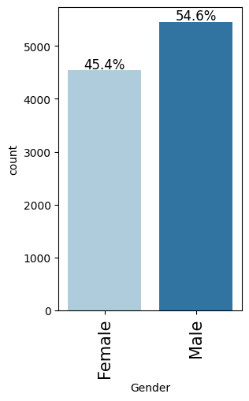

```python
labeled_barplot(ds, "Gender", perc=True)
```

**Observations**: About 55% of customers are male, while the remaining 45% are female.

#### Observations on Tenure

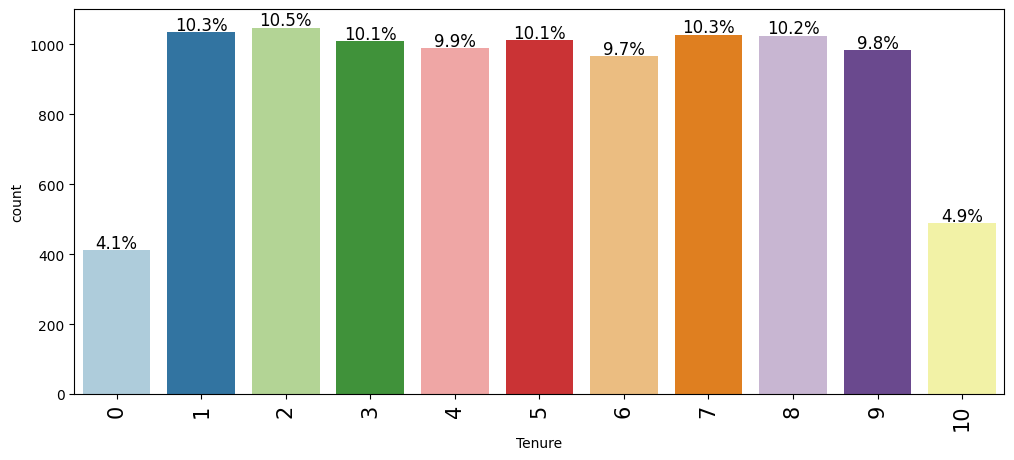

```python
labeled_barplot(ds, "Tenure", perc=True)
```

**Observations**: Bank has customers with tenure ranging from 0 to 10 years. Although new customers are fewer compared to customers with 1 or more years of tenure.

#### Observations on Number of Products

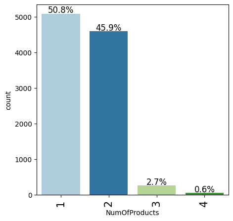

```python
labeled_barplot(ds, "NumOfProducts", perc=True)
```

**Observations**: Half of the customers use only one product, approximately 46% use two products, and just 3.3% use three or four products.

#### Observations on Has Credit Card

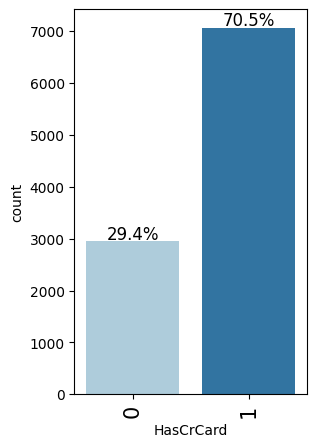

```python
labeled_barplot(ds, "HasCrCard", perc=True)
```

**Observations**: A significant majority, 70% of customers own credit cards. Whereas 29.4% of them do not own any Credit card.

#### Observations on Is Active Member

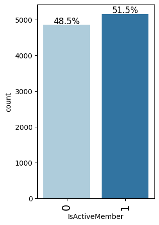

```python
labeled_barplot(ds, "IsActiveMember", perc=True)
```

**Observattions**: There are slightly more active members than inactive. Just a difference of 3%.

### Bivariate Analysis

```python
# function to plot stacked bar chart


def stacked_barplot(data, predictor, target):
    """
    Print the category counts and plot a stacked bar chart

    data: dataframe
    predictor: independent variable
    target: target variable
    """
    count = data[predictor].nunique()
    sorter = data[target].value_counts().index[-1]
    tab1 = pd.crosstab(data[predictor], data[target], margins=True).sort_values(
        by=sorter, ascending=False
    )
    print(tab1)
    print("-" * 120)
    tab = pd.crosstab(data[predictor], data[target], normalize="index").sort_values(
        by=sorter, ascending=False
    )
    tab.plot(kind="bar", stacked=True, figsize=(count + 1, 5))
    plt.legend(
        loc="lower left",
        frameon=False,
    )
    plt.legend(loc="upper left", bbox_to_anchor=(1, 1))
    plt.show()
```

#### Correlation plot

```python
# defining the list of numerical columns
cols_list = ["CreditScore","Age","Tenure","Balance","EstimatedSalary"]
```

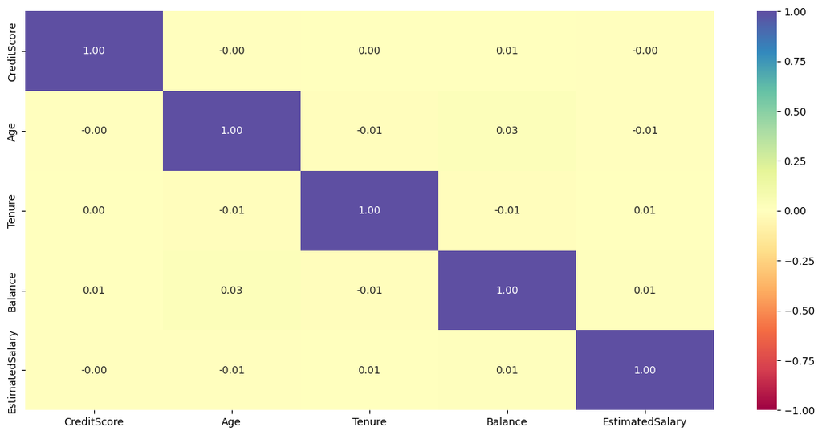

```python
plt.figure(figsize=(15, 7))
sns.heatmap(ds[cols_list].corr(), annot=True, vmin=-1, vmax=1, fmt=".2f", cmap="Spectral")
plt.show()
```

#### Exited Vs Geography

```
Exited        0     1    All
Geography
All        7963  2037  10000
Germany    1695   814   2509
France     4204   810   5014
Spain      2064   413   2477
------------------------------------------------------------------------------------------------------------------------
```

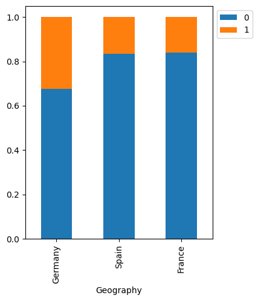

```python
stacked_barplot(ds, "Geography", "Exited" )
```

#### Exited Vs Gender

```
Exited     0     1    All
Gender
All     7963  2037  10000
Female  3404  1139   4543
Male    4559   898   5457
------------------------------------------------------------------------------------------------------------------------
```

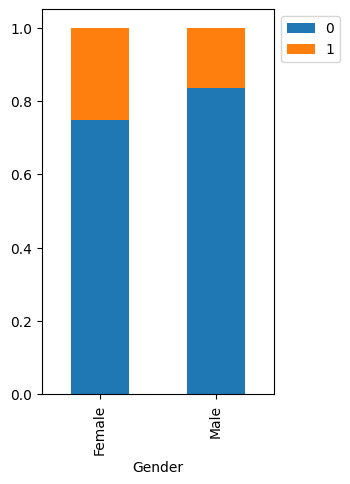

```python
stacked_barplot(ds, "Gender", "Exited" )
```

#### Exited Vs Has Credit Card

```
Exited        0     1    All
HasCrCard
All        7963  2037  10000
1          5631  1424   7055
0          2332   613   2945
------------------------------------------------------------------------------------------------------------------------
```

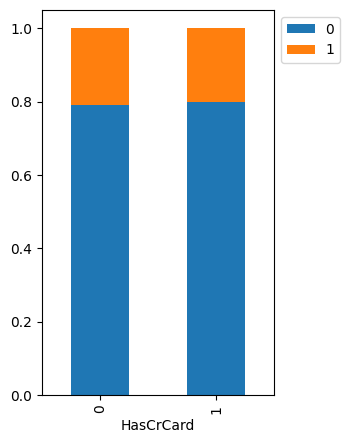

```python
stacked_barplot(ds, "HasCrCard", "Exited" )
```

#### Exited Vs Is active member

```
Exited             0     1    All
IsActiveMember
All             7963  2037  10000
0               3547  1302   4849
1               4416   735   5151
------------------------------------------------------------------------------------------------------------------------
```

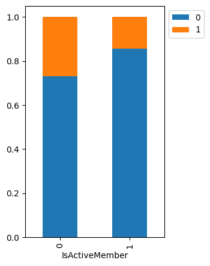

```python
stacked_barplot(ds, "IsActiveMember", "Exited" )
```

#### Exited Vs Credit Score

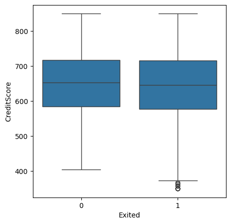

```python
plt.figure(figsize=(5,5))
sns.boxplot(y='CreditScore',x='Exited',data=ds)
plt.show()
```

#### Exited Vs Age

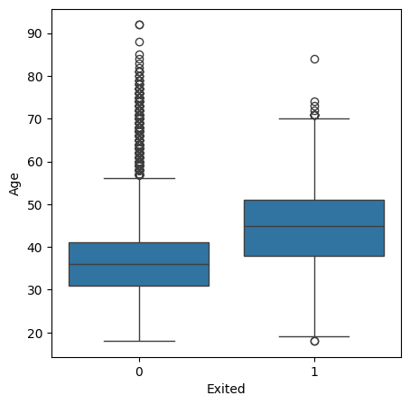

```python
plt.figure(figsize=(5,5))
sns.boxplot(y='Age',x='Exited',data=ds)
plt.show()
```

#### Exited Vs Tenure

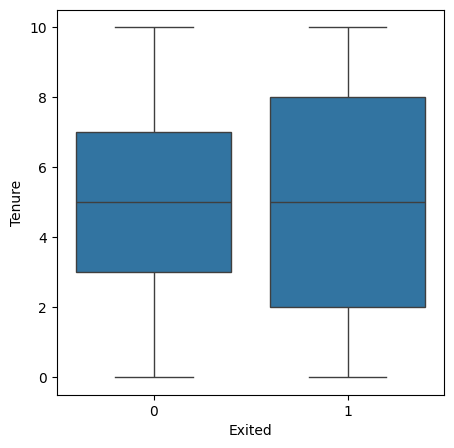

```python
plt.figure(figsize=(5,5))
sns.boxplot(y='Tenure',x='Exited',data=ds)
plt.show()
```

#### Exited Vs Balance

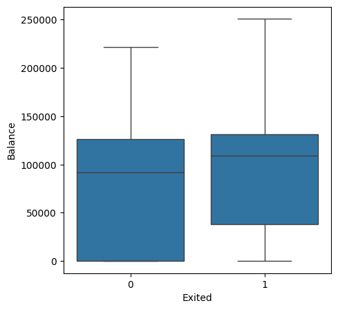

```python
plt.figure(figsize=(5,5))
sns.boxplot(y='Balance',x='Exited',data=ds)
plt.show()
```

#### Exited Vs Number of Products

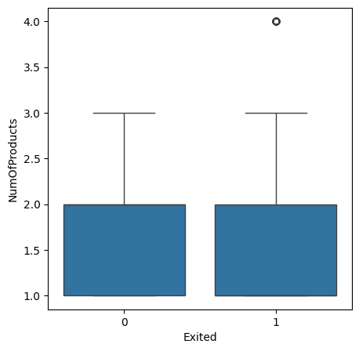

```python
plt.figure(figsize=(5,5))
sns.boxplot(y='NumOfProducts',x='Exited',data=ds)
plt.show()
```

#### Exited Vs Estimated Salary

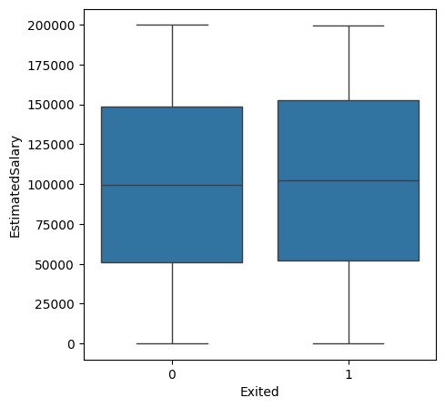

```python
plt.figure(figsize=(5,5))
sns.boxplot(y='EstimatedSalary',x='Exited',data=ds)
plt.show()
```

**Summary of Observations:**

- **Geography**: Customers from Germany exhibit the highest exit rate, while those from Spain and France have similar less exit rates.
- **Gender**: Female customers are more likely to leave the bank than male customers, making gender a valuable predictor of exits.
- **Credit Card Ownership**: Exit rates are nearly identical for customers with and without credit cards, making this a weak predictor.
- **Active Membership**: Non-active customers have a higher exit rate than active ones, making this an effective predictor for identifying potential exits.
- **Age**: Customers who existed the most fall between age 40 to 50. These customers are mostly likely to look for banks with better services.
- **Number of Products**: Though it looks like there is not much significant impact of this feature on the exist rate, there could be chance that customers with 3 or 4 products have a higher exit rate.
- There is no significant overlap or strong interdependence between the following features and the exit rate:
  - Creditscore
  - Tenure
  - Balance
  - Estimated Salary

**Therefore the Key Predictors for Customer Exits are:**

- **Age**: Customers aged 40 to 50.
- **Geography**: Customers from Germany.
- **Gender**: Female customers.
- **Active Membership**: Customers who are not active members.
- **Number of Products**: Customers with three or four products.

## Data Preprocessing

```python
ds_bak=ds.copy()
```

### Dummy Variable Creation

```python
ds = pd.get_dummies(ds,columns=ds.select_dtypes(include=["object"]).columns.tolist(),drop_first=True,dtype=float)
ds.head()
```

|  | CreditScore | Age | Tenure | Balance | NumOfProducts | HasCrCard | IsActiveMember | EstimatedSalary | Exited | Geography_Germany | Geography_Spain | Gender_Male |
| --- | --- | --- | --- | --- | --- | --- | --- | --- | --- | --- | --- | --- |
| 0 | 619 | 42 | 2 | 0.00 | 1 | 1 | 1 | 101348.88 | 1 | 0.0 | 0.0 | 0.0 |
| 1 | 608 | 41 | 1 | 83807.86 | 1 | 0 | 1 | 112542.58 | 0 | 0.0 | 1.0 | 0.0 |
| 2 | 502 | 42 | 8 | 159660.80 | 3 | 1 | 0 | 113931.57 | 1 | 0.0 | 0.0 | 0.0 |
| 3 | 699 | 39 | 1 | 0.00 | 2 | 0 | 0 | 93826.63 | 0 | 0.0 | 0.0 | 0.0 |
| 4 | 850 | 43 | 2 | 125510.82 | 1 | 1 | 1 | 79084.10 | 0 | 0.0 | 1.0 | 0.0 |

### Train-validation-test Split

```python
# Splitting the target variable and predictors

X = ds.drop(['Exited'],axis=1)
y = ds['Exited']
```

```python
# Splitting the dataset into the Training and Testing sets.

X_large, X_test, y_large, y_test = train_test_split(X, y, test_size = 0.2, random_state = 42,stratify=y,shuffle = True)
```

```python
# Splitting the training set further into the Training and Validation sets.

X_train, X_val, y_train, y_val = train_test_split(X_large, y_large, test_size = 0.2, random_state = 42,stratify=y_large, shuffle = True)
```

```python
#Printing the shapes.

print(X_train.shape,y_train.shape)
print(X_val.shape,y_val.shape)
print(X_test.shape,y_test.shape)
```

```
(6400, 11) (6400,)
(1600, 11) (1600,)
(2000, 11) (2000,)
```

### Data Normalization

Since all the numerical values are on a different scale, so we will be scaling all the numerical values to bring them to the same scale i.e. for columns CreditScore, Age, Tenure, Balance, EstimatedSalary.

```python
# creating an instance of the standard scaler
sc = StandardScaler()

X_train[cols_list] = sc.fit_transform(X_train[cols_list])
X_val[cols_list] = sc.transform(X_val[cols_list])
X_test[cols_list] = sc.transform(X_test[cols_list])
```

## Model Building

### Model Evaluation Criterion

**A model can make wrong predictions in the following ways:**

- Case 1: Predicting a customer will be leaving the bank and joining another service provider when they will not.
  - This is a false positive (Type I error).
  - Impact: The bank may unnecessarily invest resources (e.g., marketing efforts, retention offers) to retain a customer who was not planning to leave.
- Case 2: Predicting a customer will not be leaving the bank when they are actually planning to exit and join another service provider.
  - This is a false negative (Type II error).
  - Impact: The bank misses the opportunity to intervene and prevent a customer from leaving, resulting in revenue loss and potential long-term business impact.

**Which case is more important?**

- Case 2 is generally more critical because losing a customer (and revenue) is typically worse for the bank than mistakenly trying to retain a customer who wasn't planning to leave.
- Recall focuses on minimizing false negatives, making it the relevant metric for Case 2.

**Conclusion**

Prioritizing Case 2 and optimizing for **recall** ensures the bank identifies as many customers likely to leave as possible, even if it means some additional retention efforts for customers not at risk.

**Let's create a function for plotting the confusion matrix**

```python
def make_confusion_matrix(cf,
                          group_names=None,
                          categories='auto',
                          count=True,
                          percent=True,
                          cbar=True,
                          xyticks=True,
                          xyplotlabels=True,
                          sum_stats=True,
                          figsize=None,
                          title=None):
    '''
    This function will make a pretty plot of an sklearn Confusion Matrix cm using a Seaborn heatmap visualization.
    Arguments
    '''


    # CODE TO GENERATE TEXT INSIDE EACH SQUARE
    blanks = ['' for i in range(cf.size)]

    if group_names and len(group_names)==cf.size:
        group_labels = ["{}\n".format(value) for value in group_names]
    else:
        group_labels = blanks

    if count:
        group_counts = ["{0:0.0f}\n".format(value) for value in cf.flatten()]
    else:
        group_counts = blanks

    if percent:
        group_percentages = ["{0:.2%}".format(value) for value in cf.flatten()/np.sum(cf)]
    else:
        group_percentages = blanks

    box_labels = [f"{v1}{v2}{v3}".strip() for v1, v2, v3 in zip(group_labels,group_counts,group_percentages)]
    box_labels = np.asarray(box_labels).reshape(cf.shape[0],cf.shape[1])


    # CODE TO GENERATE SUMMARY STATISTICS & TEXT FOR SUMMARY STATS
    if sum_stats:
        #Accuracy is sum of diagonal divided by total observations
        accuracy  = np.trace(cf) / float(np.sum(cf))



    # SET FIGURE PARAMETERS ACCORDING TO OTHER ARGUMENTS
    if figsize==None:
        #Get default figure size if not set
        figsize = plt.rcParams.get('figure.figsize')

    if xyticks==False:
        #Do not show categories if xyticks is False
        categories=False


    # MAKE THE HEATMAP VISUALIZATION
    plt.figure(figsize=figsize)
    sns.heatmap(cf,annot=box_labels,fmt="",cbar=cbar,xticklabels=categories,yticklabels=categories)


    if title:
        plt.title(title)
```

Let's create two blank dataframes that will store the recall values for all the models we build.

```python
train_metric_df = pd.DataFrame(columns=["recall"])
valid_metric_df = pd.DataFrame(columns=["recall"])
```

### Neural Network with SGD Optimizer

```python
backend.clear_session()

#Fixing the seed for random number generators so that we can ensure we receive the same output everytime
np.random.seed(2)
random.seed(2)
tf.random.set_seed(2)
```

```python
#Initializing the neural network
model_0 = Sequential()
# Adding the input layer with 64 neurons and relu as activation function
model_0.add(Dense(64, activation='relu', input_dim = X_train.shape[1]))
# Adding the second hidden layer with 32 neurons, relu as activation function
model_0.add(Dense(32, activation='relu'))
# Adding the output layer with one neuron and Sigmoid as activation
model_0.add(Dense(1, activation = 'sigmoid'))
```

```python
# Compiling the model with 'Binary cross entropy' as loss function and 'recall' as the metric
optimizer = tf.keras.optimizers.SGD()
model_0.compile(loss='binary_crossentropy', optimizer=optimizer,metrics=['recall'])
```

```python
model_0.summary()
```

```
Model: "sequential"
```

```
┏━━━━━━━━━━━━━━━━━━━━━━━━━━━━━━━━━━━━━━┳━━━━━━━━━━━━━━━━━━━━━━━━━━━━━┳━━━━━━━━━━━━━━━━━┓
┃ Layer (type)                         ┃ Output Shape                ┃         Param # ┃
┡━━━━━━━━━━━━━━━━━━━━━━━━━━━━━━━━━━━━━━╇━━━━━━━━━━━━━━━━━━━━━━━━━━━━━╇━━━━━━━━━━━━━━━━━┩
│ dense (Dense)                        │ (None, 64)                  │             768 │
├──────────────────────────────────────┼─────────────────────────────┼─────────────────┤
│ dense_1 (Dense)                      │ (None, 32)                  │           2,080 │
├──────────────────────────────────────┼─────────────────────────────┼─────────────────┤
│ dense_2 (Dense)                      │ (None, 1)                   │              33 │
└──────────────────────────────────────┴─────────────────────────────┴─────────────────┘
```

```
 Total params: 2,881 (11.25 KB)
```

```
 Trainable params: 2,881 (11.25 KB)
```

```
 Non-trainable params: 0 (0.00 B)
```

```python
# Fitting the model on training and validation with 25 epochs and batch_size 64.

history_0 = model_0.fit(
    X_train, y_train,
    batch_size=64,
    validation_data=(X_val,y_val),
    epochs=25,
    verbose=1
)
```

```
100/100 ━━━━━━━━━━━━━━━━━━━━ 3s 10ms/step - loss: 0.5880 - recall: 0.0378 - val_loss: 0.5030 - val_recall: 0.0000e+00
100/100 ━━━━━━━━━━━━━━━━━━━━ 1s 2ms/step - loss: 0.5029 - recall: 0.0000e+00 - val_loss: 0.4834 - val_recall: 0.0000e+00
100/100 ━━━━━━━━━━━━━━━━━━━━ 0s 2ms/step - loss: 0.4842 - recall: 0.0000e+00 - val_loss: 0.4712 - val_recall: 0.0000e+00
100/100 ━━━━━━━━━━━━━━━━━━━━ 0s 2ms/step - loss: 0.4707 - recall: 0.0016 - val_loss: 0.4621 - val_recall: 0.0031
100/100 ━━━━━━━━━━━━━━━━━━━━ 0s 2ms/step - loss: 0.4601 - recall: 0.0055 - val_loss: 0.4551 - val_recall: 0.0092
100/100 ━━━━━━━━━━━━━━━━━━━━ 0s 2ms/step - loss: 0.4518 - recall: 0.0145 - val_loss: 0.4496 - val_recall: 0.0307
100/100 ━━━━━━━━━━━━━━━━━━━━ 0s 2ms/step - loss: 0.4452 - recall: 0.0369 - val_loss: 0.4454 - val_recall: 0.0460
100/100 ━━━━━━━━━━━━━━━━━━━━ 0s 2ms/step - loss: 0.4400 - recall: 0.0696 - val_loss: 0.4422 - val_recall: 0.0613
100/100 ━━━━━━━━━━━━━━━━━━━━ 0s 2ms/step - loss: 0.4357 - recall: 0.1061 - val_loss: 0.4398 - val_recall: 0.0675
100/100 ━━━━━━━━━━━━━━━━━━━━ 0s 2ms/step - loss: 0.4323 - recall: 0.1186 - val_loss: 0.4379 - val_recall: 0.0890
100/100 ━━━━━━━━━━━━━━━━━━━━ 0s 3ms/step - loss: 0.4294 - recall: 0.1349 - val_loss: 0.4363 - val_recall: 0.0920
100/100 ━━━━━━━━━━━━━━━━━━━━ 1s 3ms/step - loss: 0.4269 - recall: 0.1475 - val_loss: 0.4349 - val_recall: 0.1166
100/100 ━━━━━━━━━━━━━━━━━━━━ 0s 3ms/step - loss: 0.4247 - recall: 0.1605 - val_loss: 0.4337 - val_recall: 0.1196
100/100 ━━━━━━━━━━━━━━━━━━━━ 1s 3ms/step - loss: 0.4228 - recall: 0.1749 - val_loss: 0.4326 - val_recall: 0.1380
100/100 ━━━━━━━━━━━━━━━━━━━━ 0s 4ms/step - loss: 0.4210 - recall: 0.1936 - val_loss: 0.4316 - val_recall: 0.1350
100/100 ━━━━━━━━━━━━━━━━━━━━ 0s 3ms/step - loss: 0.4195 - recall: 0.2021 - val_loss: 0.4307 - val_recall: 0.1472
100/100 ━━━━━━━━━━━━━━━━━━━━ 1s 3ms/step - loss: 0.4181 - recall: 0.2074 - val_loss: 0.4298 - val_recall: 0.1503
100/100 ━━━━━━━━━━━━━━━━━━━━ 0s 2ms/step - loss: 0.4168 - recall: 0.2164 - val_loss: 0.4290 - val_recall: 0.1534
100/100 ━━━━━━━━━━━━━━━━━━━━ 0s 2ms/step - loss: 0.4156 - recall: 0.2262 - val_loss: 0.4282 - val_recall: 0.1595
100/100 ━━━━━━━━━━━━━━━━━━━━ 0s 2ms/step - loss: 0.4145 - recall: 0.2352 - val_loss: 0.4275 - val_recall: 0.1656
100/100 ━━━━━━━━━━━━━━━━━━━━ 0s 2ms/step - loss: 0.4135 - recall: 0.2462 - val_loss: 0.4268 - val_recall: 0.1748
100/100 ━━━━━━━━━━━━━━━━━━━━ 0s 2ms/step - loss: 0.4125 - recall: 0.2527 - val_loss: 0.4262 - val_recall: 0.1840
100/100 ━━━━━━━━━━━━━━━━━━━━ 0s 2ms/step - loss: 0.4116 - recall: 0.2556 - val_loss: 0.4256 - val_recall: 0.1902
100/100 ━━━━━━━━━━━━━━━━━━━━ 0s 2ms/step - loss: 0.4107 - recall: 0.2611 - val_loss: 0.4250 - val_recall: 0.1902
100/100 ━━━━━━━━━━━━━━━━━━━━ 0s 2ms/step - loss: 0.4099 - recall: 0.2639 - val_loss: 0.4244 - val_recall: 0.1994
```

**Loss function**

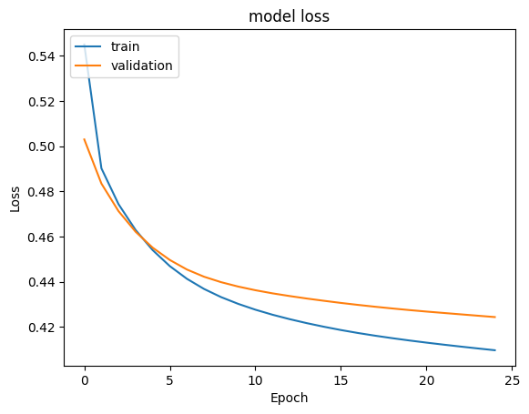

```python
#Plotting Train Loss vs Validation Loss
plt.plot(history_0.history['loss'])
plt.plot(history_0.history['val_loss'])
plt.title('model loss')
plt.ylabel('Loss')
plt.xlabel('Epoch')
plt.legend(['train', 'validation'], loc='upper left')
plt.show()
```

**Recall**

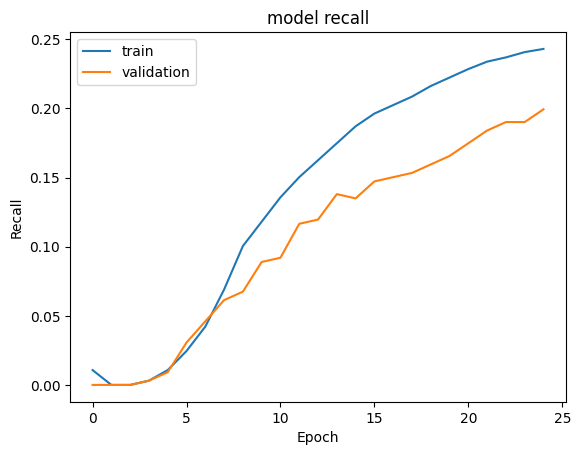

```python
#Plotting Train recall vs Validation recall
plt.plot(history_0.history['recall'])
plt.plot(history_0.history['val_recall'])
plt.title('model recall')
plt.ylabel('Recall')
plt.xlabel('Epoch')
plt.legend(['train', 'validation'], loc='upper left')
plt.show()
```

```python
#Predicting the results using best as a threshold
y_train_pred = model_0.predict(X_train)
y_train_pred = (y_train_pred > 0.5)
y_train_pred
```

```
200/200 ━━━━━━━━━━━━━━━━━━━━ 1s 1ms/step
```

```
array([[False],
       [False],
       [False],
       ...,
       [False],
       [False],
       [False]])
```

```python
#Predicting the results using best as a threshold
y_val_pred = model_0.predict(X_val)
y_val_pred = (y_val_pred > 0.5)
y_val_pred
```

```
50/50 ━━━━━━━━━━━━━━━━━━━━ 0s 1ms/step
```

```
array([[False],
       [False],
       [False],
       ...,
       [False],
       [False],
       [False]])
```

```python
model_name = "NN with SGD"

train_metric_df.loc[model_name] = recall_score(y_train, y_train_pred)
valid_metric_df.loc[model_name] = recall_score(y_val, y_val_pred)
```

**Classification report**

```python
# Classification report to check the model's performance on training dataset
cr = classification_report(y_train, y_train_pred)
print(cr)
```

```
              precision    recall  f1-score   support

           0       0.83      0.97      0.90      5096
           1       0.68      0.24      0.36      1304

    accuracy                           0.82      6400
   macro avg       0.76      0.61      0.63      6400
weighted avg       0.80      0.82      0.79      6400
```

```python
# Classification report to check the model's performance on validation dataset
cr=classification_report(y_val, y_val_pred)
print(cr)
```

```
              precision    recall  f1-score   support

           0       0.83      0.97      0.89      1274
           1       0.66      0.20      0.31       326

    accuracy                           0.82      1600
   macro avg       0.74      0.59      0.60      1600
weighted avg       0.79      0.82      0.77      1600
```

**Confusion matrix**

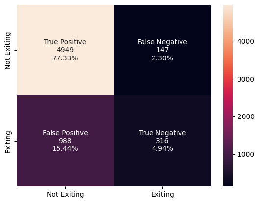

```python
# Displaying confusion matrix for the performance on Training dataset
cm=confusion_matrix(y_train, y_train_pred)
labels = ['True Positive','False Negative','False Positive','True Negative']
categories = [ 'Not Exiting','Exiting']
make_confusion_matrix(cm, group_names=labels, categories=categories)
```

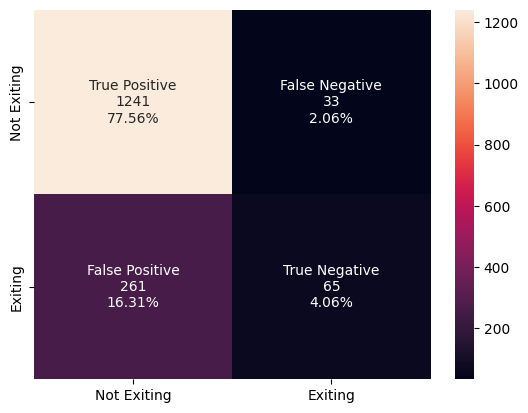

```python
# Displaying confusion matrix for the performance on Validation dataset
cm=confusion_matrix(y_val, y_val_pred)
labels = ['True Positive','False Negative','False Positive','True Negative']
categories = [ 'Not Exiting','Exiting']
make_confusion_matrix(cm, group_names=labels, categories=categories)
```

**Observations:**

1. Recall for Class 1 (Exited Customers):

[output not shown]

2. Class Imbalance Impact:
   - Class 0 (Non-Exited Customers) has a much higher recall (97% on both datasets) because the model is biased toward predicting the majority class.
   - Since class 1 is the minority class, the model's recall for this class is poor, likely due to the imbalance in the dataset.
3. Overall Performance:
   - While the overall accuracy is 82% for both datasets, this metric is misleading in this context. The imbalance skews accuracy, making it less reflective of the model's ability to predict the minority class.

**Recommendations:**

1. Focus on Improving Recall for Class 1: - Since identifying customers who are likely to exit is critical, the model needs optimization to improve recall for class 1.
2. Address Class Imbalance: - Use techniques like oversampling (e.g., SMOTE) or undersampling, or adjust class weights in the model to give higher importance to class 1.
3. Adjust the Decision Threshold: - Lowering the threshold for predicting class 1 may help improve recall, though this could reduce precision for the class.
4. Track Recall as a Key Metric:

```
- While precision and f1-score are also important, recall for class 1 should remain the primary focus, given the use case of predicting customer exits.
```

## Model Performance Improvement

### Neural Network with Adam Optimizer

```python
backend.clear_session()
#Fixing the seed for random number generators so that we can ensure we receive the same output everytime
np.random.seed(2)
random.seed(2)
tf.random.set_seed(2)
```

```python
#Initializing the neural network
model_1 = Sequential()
# Adding the first hidden layer with 64 neurons, relu as activation function
model_1.add(Dense(64,activation='relu',input_dim = X_train.shape[1]))
# Adding the second hidden layer with 32 neurons, relu as activation function
model_1.add(Dense(32,activation='relu'))
# Adding the output layer with one neuron and Sigmoid as activation function
model_1.add(Dense(1, activation = 'sigmoid'))
```

```python
# Compiling the model with 'Binary cross entropy' as loss function, 'recall' as the metric and Adam as the Optimizer
model_1.compile(loss='binary_crossentropy', optimizer='Adam',metrics=['recall'])
```

```python
model_1.summary()
```

```
Model: "sequential"
```

```
┏━━━━━━━━━━━━━━━━━━━━━━━━━━━━━━━━━━━━━━┳━━━━━━━━━━━━━━━━━━━━━━━━━━━━━┳━━━━━━━━━━━━━━━━━┓
┃ Layer (type)                         ┃ Output Shape                ┃         Param # ┃
┡━━━━━━━━━━━━━━━━━━━━━━━━━━━━━━━━━━━━━━╇━━━━━━━━━━━━━━━━━━━━━━━━━━━━━╇━━━━━━━━━━━━━━━━━┩
│ dense (Dense)                        │ (None, 64)                  │             768 │
├──────────────────────────────────────┼─────────────────────────────┼─────────────────┤
│ dense_1 (Dense)                      │ (None, 32)                  │           2,080 │
├──────────────────────────────────────┼─────────────────────────────┼─────────────────┤
│ dense_2 (Dense)                      │ (None, 1)                   │              33 │
└──────────────────────────────────────┴─────────────────────────────┴─────────────────┘
```

```
 Total params: 2,881 (11.25 KB)
```

```
 Trainable params: 2,881 (11.25 KB)
```

```
 Non-trainable params: 0 (0.00 B)
```

```python
# Fitting the model on training and validation with 25 epochs and batch_size 64.

history_1 = model_1.fit(
    X_train,y_train,
    batch_size=64,
    validation_data=(X_val,y_val),
    epochs=25,
    verbose=1
)
```

```
100/100 ━━━━━━━━━━━━━━━━━━━━ 2s 6ms/step - loss: 0.5181 - recall: 0.0326 - val_loss: 0.4357 - val_recall: 0.1166
100/100 ━━━━━━━━━━━━━━━━━━━━ 0s 2ms/step - loss: 0.4230 - recall: 0.2114 - val_loss: 0.4257 - val_recall: 0.2055
100/100 ━━━━━━━━━━━━━━━━━━━━ 0s 2ms/step - loss: 0.4087 - recall: 0.2939 - val_loss: 0.4183 - val_recall: 0.2270
100/100 ━━━━━━━━━━━━━━━━━━━━ 0s 2ms/step - loss: 0.3982 - recall: 0.3283 - val_loss: 0.4112 - val_recall: 0.2853
100/100 ━━━━━━━━━━━━━━━━━━━━ 0s 2ms/step - loss: 0.3889 - recall: 0.3574 - val_loss: 0.4044 - val_recall: 0.3282
100/100 ━━━━━━━━━━━━━━━━━━━━ 0s 2ms/step - loss: 0.3804 - recall: 0.3792 - val_loss: 0.3988 - val_recall: 0.3313
100/100 ━━━━━━━━━━━━━━━━━━━━ 0s 2ms/step - loss: 0.3730 - recall: 0.3991 - val_loss: 0.3934 - val_recall: 0.3405
100/100 ━━━━━━━━━━━━━━━━━━━━ 0s 2ms/step - loss: 0.3663 - recall: 0.4135 - val_loss: 0.3889 - val_recall: 0.3497
100/100 ━━━━━━━━━━━━━━━━━━━━ 0s 2ms/step - loss: 0.3605 - recall: 0.4265 - val_loss: 0.3853 - val_recall: 0.3681
100/100 ━━━━━━━━━━━━━━━━━━━━ 0s 2ms/step - loss: 0.3555 - recall: 0.4412 - val_loss: 0.3820 - val_recall: 0.3834
100/100 ━━━━━━━━━━━━━━━━━━━━ 0s 2ms/step - loss: 0.3507 - recall: 0.4489 - val_loss: 0.3784 - val_recall: 0.3804
100/100 ━━━━━━━━━━━━━━━━━━━━ 0s 2ms/step - loss: 0.3461 - recall: 0.4672 - val_loss: 0.3754 - val_recall: 0.3896
100/100 ━━━━━━━━━━━━━━━━━━━━ 0s 2ms/step - loss: 0.3418 - recall: 0.4709 - val_loss: 0.3726 - val_recall: 0.3926
100/100 ━━━━━━━━━━━━━━━━━━━━ 0s 3ms/step - loss: 0.3376 - recall: 0.4701 - val_loss: 0.3703 - val_recall: 0.3957
100/100 ━━━━━━━━━━━━━━━━━━━━ 0s 3ms/step - loss: 0.3339 - recall: 0.4813 - val_loss: 0.3681 - val_recall: 0.3957
100/100 ━━━━━━━━━━━━━━━━━━━━ 1s 3ms/step - loss: 0.3304 - recall: 0.4891 - val_loss: 0.3662 - val_recall: 0.3988
100/100 ━━━━━━━━━━━━━━━━━━━━ 1s 3ms/step - loss: 0.3273 - recall: 0.4925 - val_loss: 0.3649 - val_recall: 0.4049
100/100 ━━━━━━━━━━━━━━━━━━━━ 0s 3ms/step - loss: 0.3246 - recall: 0.4985 - val_loss: 0.3637 - val_recall: 0.4110
100/100 ━━━━━━━━━━━━━━━━━━━━ 0s 3ms/step - loss: 0.3220 - recall: 0.5014 - val_loss: 0.3629 - val_recall: 0.4110
100/100 ━━━━━━━━━━━━━━━━━━━━ 1s 3ms/step - loss: 0.3197 - recall: 0.5093 - val_loss: 0.3622 - val_recall: 0.4141
100/100 ━━━━━━━━━━━━━━━━━━━━ 0s 2ms/step - loss: 0.3177 - recall: 0.5141 - val_loss: 0.3621 - val_recall: 0.4172
100/100 ━━━━━━━━━━━━━━━━━━━━ 0s 2ms/step - loss: 0.3158 - recall: 0.5171 - val_loss: 0.3620 - val_recall: 0.4141
100/100 ━━━━━━━━━━━━━━━━━━━━ 0s 2ms/step - loss: 0.3142 - recall: 0.5180 - val_loss: 0.3620 - val_recall: 0.4141
100/100 ━━━━━━━━━━━━━━━━━━━━ 0s 2ms/step - loss: 0.3128 - recall: 0.5230 - val_loss: 0.3621 - val_recall: 0.4172
100/100 ━━━━━━━━━━━━━━━━━━━━ 0s 2ms/step - loss: 0.3114 - recall: 0.5266 - val_loss: 0.3620 - val_recall: 0.4202
```

**Loss function**

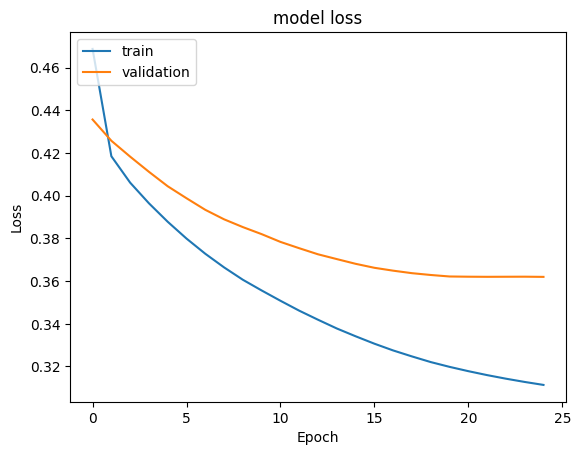

```python
#Plotting Train Loss vs Validation Loss
plt.plot(history_1.history['loss'])
plt.plot(history_1.history['val_loss'])
plt.title('model loss')
plt.ylabel('Loss')
plt.xlabel('Epoch')
plt.legend(['train', 'validation'], loc='upper left')
plt.show()
```

**Recall**

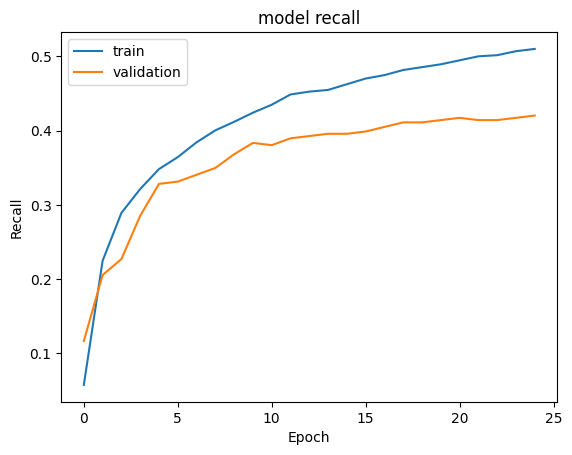

```python
#Plotting Train recall vs Validation recall
plt.plot(history_1.history['recall'])
plt.plot(history_1.history['val_recall'])
plt.title('model recall')
plt.ylabel('Recall')
plt.xlabel('Epoch')
plt.legend(['train', 'validation'], loc='upper left')
plt.show()
```

```python
#Predicting the results using 0.5 as the threshold
y_train_pred = model_1.predict(X_train)
y_train_pred = (y_train_pred > 0.5)
y_train_pred
```

```
200/200 ━━━━━━━━━━━━━━━━━━━━ 0s 1ms/step
```

```
array([[False],
       [False],
       [False],
       ...,
       [False],
       [ True],
       [False]])
```

```python
#Predicting the results using 0.5 as the threshold
y_val_pred = model_1.predict(X_val)
y_val_pred = (y_val_pred > 0.5)
y_val_pred
```

```
50/50 ━━━━━━━━━━━━━━━━━━━━ 0s 1ms/step
```

```
array([[False],
       [False],
       [False],
       ...,
       [False],
       [False],
       [ True]])
```

```python
model_name = "NN with Adam"

train_metric_df.loc[model_name] = recall_score(y_train,y_train_pred)
valid_metric_df.loc[model_name] = recall_score(y_val,y_val_pred)
```

**Classification report**

```python
#Classification report

cr=classification_report(y_train,y_train_pred)
print(cr)
```

```
              precision    recall  f1-score   support

           0       0.89      0.96      0.92      5096
           1       0.78      0.53      0.63      1304

    accuracy                           0.87      6400
   macro avg       0.83      0.74      0.78      6400
weighted avg       0.87      0.87      0.86      6400
```

```python
#classification report

cr=classification_report(y_val,y_val_pred)
print(cr)
```

```
              precision    recall  f1-score   support

           0       0.87      0.96      0.91      1274
           1       0.72      0.42      0.53       326

    accuracy                           0.85      1600
   macro avg       0.80      0.69      0.72      1600
weighted avg       0.84      0.85      0.83      1600
```

**Confusion matrix**

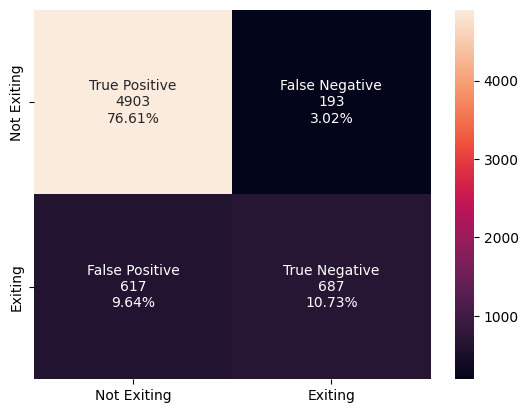

```python
# Displaying confusion matrix for the performance on Training dataset
cm=confusion_matrix(y_train, y_train_pred)
labels = ['True Positive','False Negative','False Positive','True Negative']
categories = [ 'Not Exiting','Exiting']
make_confusion_matrix(cm, group_names=labels, categories=categories)
```

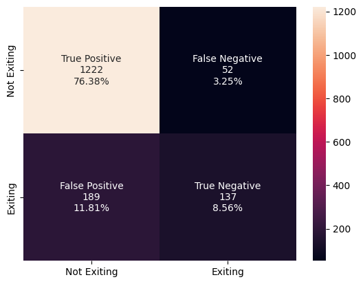

```python
# Displaying confusion matrix for the performance on Validation dataset
cm=confusion_matrix(y_val, y_val_pred)
labels = ['True Positive','False Negative','False Positive','True Negative']
categories = [ 'Not Exiting','Exiting']
make_confusion_matrix(cm, group_names=labels, categories=categories)
```

**Observations:**

Model_1 with Adam Optimizer outperforms Model_0 with SGD Optimizer in recall for identifying exiting customers, which is critical in this scenario. While Model_0 achieves high recall for non-exiting customers, its inability to capture exiting customers (class 1) makes it less effective. Model_1 provides a more balanced and practical solution for addressing the business objective.